# Project: Investigate a Dataset - No-show Appointments Dataset Analysis

## Exploratory Data Analysis

From the list of factors represented in the columns, they can be categoried into two; the dependent variables and the independent variables.  
I choose my categories to be as follows;  
**Dependent Variable**  
No-show  
**Independent Variables**

1. Scholarship
2. Neighbourhood
3. Patient's condition; Hipertension,Diabetes, Alcoholism, Handcap
4. Age

So we will investigate the relationship between the depedepent variable with each of the indipendent variable. But first let us get a general view the histogram for the dataset;

### Research Question 1 : Which of these factors can be used to predict if the patient will show up?

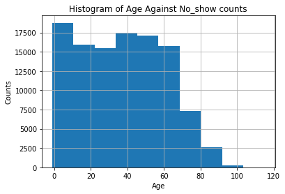

```python
def display_histogram(column,title,xlabel,ylabel):
    column.hist()
    plt.title(title)
    plt.xlabel(xlabel)
    plt.ylabel(ylabel)
    """Input the column name and the output will be a histogram"""
display_histogram(df.Age,'Histogram of Age Against No_show counts','Age','Counts' )
```

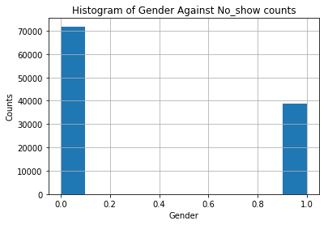

```python
display_histogram(df.Gender,'Histogram of Gender Against No_show counts','Gender','Counts' )
```

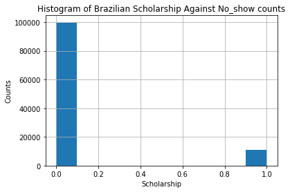

```python
display_histogram(df.Scholarship,'Histogram of Brazilian Scholarship Against No_show counts','Scholarship','Counts' )
```

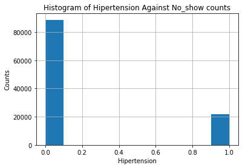

```python
display_histogram(df.Hipertension,'Histogram of Hipertension Against No_show counts','Hipertension','Counts' )
```

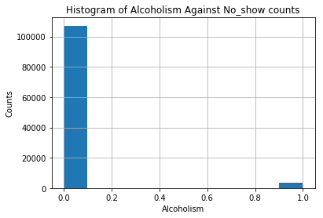

```python
display_histogram(df.Alcoholism,'Histogram of Alcoholism Against No_show counts','Alcoholism','Counts' )
```

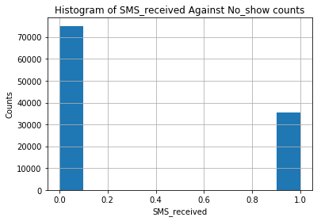

```python
display_histogram(df.SMS_received,'Histogram of SMS_received Against No_show counts','SMS_received','Counts' )
```

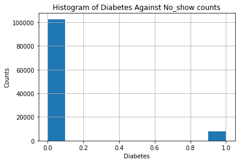

```python
display_histogram(df.Diabetes,'Histogram of Diabetes Against No_show counts','Diabetes','Counts' )
```

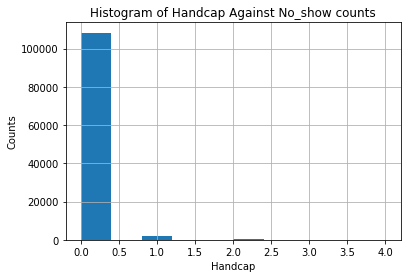

```python
display_histogram(df.Handcap,'Histogram of Handcap Against No_show counts','Handcap','Counts' )
```

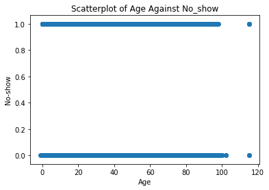

```python
def display_scatterplot(x,y,title,xlabel,ylabel):
    plt.scatter(x=x,y=y)
    plt.title(title)
    plt.xlabel(xlabel)
    plt.ylabel(ylabel)
    """Input the column name and the output will be a histogram"""
display_scatterplot(df.Age,df.noshow,'Scatterplot of Age Against No_show','Age','No-show' )
```

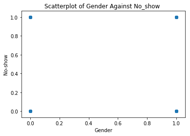

```python
display_scatterplot(df.Gender,df.noshow,'Scatterplot of Gender Against No_show ','Gender','No-show' )
```

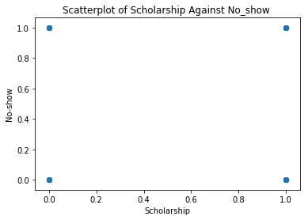

```python
display_scatterplot(df.Scholarship,df.noshow,'Scatterplot of Scholarship Against No_show ','Scholarship','No-show' )
```

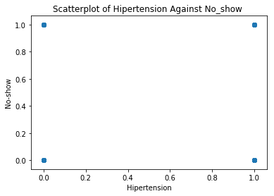

```python
display_scatterplot(df.Hipertension,df.noshow,'Scatterplot of Hipertension Against No_show ','Hipertension','No-show' )
```

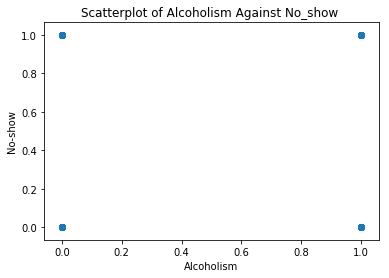

```python
display_scatterplot(df.Alcoholism,df.noshow,'Scatterplot of Alcoholism Against No_show ','Alcoholism','No-show' )
```

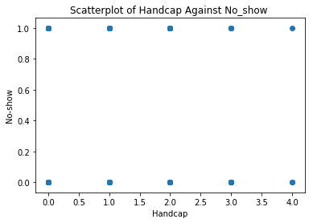

```python
display_scatterplot(df.Handcap,df.noshow,'Scatterplot of Handcap Against No_show ','Handcap','No-show' )
```

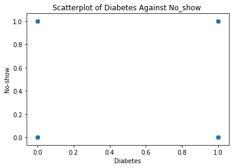

```python
display_scatterplot(df.Diabetes,df.noshow,'Scatterplot of Diabetes Against No_show ','Diabetes','No-show' )
```

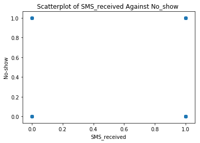

```python
display_scatterplot(df.SMS_received,df.noshow,'Scatterplot of SMS_received Against No_show ','SMS_received','No-show' )
```